# Microbiome

2024-06-12

# Installer et charger les packages

```r
#install.packages("rmarkdown")
#install.packages("tidyverse")
#install.packages("vegan")
#install.packages("BiocManager")

#if(!requireNamespace("BiocManager")){
#  install.packages("BiocManager")
#}

#BiocManager::install("phyloseq")


library(tidyverse); library(vegan); library(phyloseq)
```

> Charger l’objet au format phyloseq et nettoyer les noms

```r
# Charger ANT3814_ps.rds dans Posit Cloud en cliquant sur "Upload" depuis l'onglet "Files" dans la fenêtre en bas à droite

ANT3814_ps <- readRDS("~/Dropbox/Montreal/TEACHING/ANT_3814_ComputationalCourse/GIT/PROBLEM_SETS/ANT3814_ps.rds")

# Le code de ce bloc nettoie les noms de taxonomie désordonnés dans le jeu de données pour qu'ils soient lisibles comme ASV_001, ASV_002, etc.

ANT3814_ps_rename <- ANT3814_ps
n_seqs <- seq(ntaxa(ANT3814_ps_rename))
len_n_seqs <- nchar(max(n_seqs))
taxa_names(ANT3814_ps_rename) <- paste("ASV", formatC(n_seqs,
                                            width = len_n_seqs,
                                            flag = "0"), sep = "_")


ANT3814_ps <- ANT3814_ps_rename
taxa_names(ANT3814_ps)
```

[output not shown]

[output cut: 95 more lines]

> Regardons les données

```r
# Voir les métadonnées
view(sample_data(ANT3814_ps))

# Voir les différents types de microbes dans le jeu de données
TAXONOMY_TABLE <-tax_table(ANT3814_ps)
view(TAXONOMY_TABLE)

# Voir le nombre de chaque type de microbe dans chaque échantillon
OTU_TABLE <-otu_table(ANT3814_ps)
view(OTU_TABLE)

# Voir le nombre de lectures de séquençage dans chaque échantillon
sort(sample_sums(ANT3814_ps))
```

```
## L3S242 L3S341 L3S360 L3S313 L3S294 L3S378 L2S309 L5S240 L5S155 L5S174 L5S203
##    897    962    969   1103   1225   1249   1419   1792   1800   1953   2112
## L5S104 L2S357 L5S222 L2S204 L2S222 L2S155 L2S382 L2S175 L2S240  L6S68 L1S257
##   2227   2373   2521   3158   3187   3932   4089   4386   5061   5980   6388
## L1S281  L6S20  L6S93   L1S8 L1S140 L1S105  L1S76 L1S208 L4S112  L1S57  L4S63
##   6615   6855   6953   7033   7163   7780   7867   8152   8340   8702   9744
## L4S137
##   9820
```

# QUESTION 1 : Qu’est-ce que l’ASV_228 ? Dans combien d’échantillons est-il présent ? Pouvons-nous identifier avec confiance son espèce ?

# QUESTION 2 : Qu’est-ce que l’ASV_221 ? Dans combien d’échantillons est-il présent ? Pouvons-nous identifier avec confiance son espèce ?

# QUESTION 3 : Combien d’échantillons ont plus de 1000 lectures de séquençage ?

> Créer une courbe de raréfaction du nombre d’ASV pour chaque échantillon. Cela montre combien de nouveaux ASV sont trouvés avec plus de séquençage de l’ADN.

```r
sort(sample_sums(ANT3814_ps))
```

```
## L3S242 L3S341 L3S360 L3S313 L3S294 L3S378 L2S309 L5S240 L5S155 L5S174 L5S203
##    897    962    969   1103   1225   1249   1419   1792   1800   1953   2112
## L5S104 L2S357 L5S222 L2S204 L2S222 L2S155 L2S382 L2S175 L2S240  L6S68 L1S257
##   2227   2373   2521   3158   3187   3932   4089   4386   5061   5980   6388
## L1S281  L6S20  L6S93   L1S8 L1S140 L1S105  L1S76 L1S208 L4S112  L1S57  L4S63
##   6615   6855   6953   7033   7163   7780   7867   8152   8340   8702   9744
## L4S137
##   9820
```

```r
tab <- otu_table(ANT3814_ps)
class(tab) <- "matrix" # as.matrix() ne fera rien
```

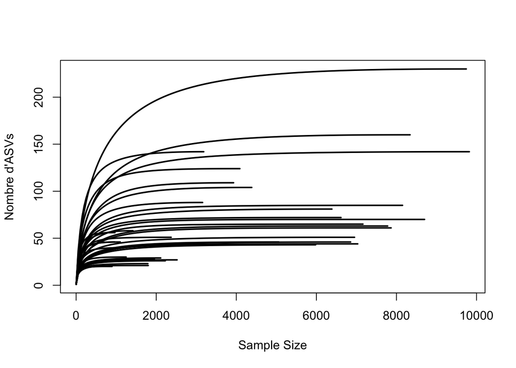

```r
## vous obtenez un avertissement ici, mais c'est ce dont nous avons besoin
tab <- t(tab) # transposer les observations en lignes

rarecurve(tab, step=50, lwd=2, ylab="Nombre d'ASVs",  label=F, cex=0.5)
```

# QUESTION 4 : En général, autour de quel nombre de lectures de séquençage (la valeur sur l’axe des X) le nombre d’ASV se stabilise-t-il ?

> Raréfions le jeu de données à 1103 lectures de séquençage (en excluant 3 échantillons). Cela sélectionnera aléatoirement 1103 lectures de séquençage de chaque échantillon pour permettre une comparaison uniforme de la diversité microbienne dans tous les échantillons.

```r
set.seed(111) # garder le résultat reproductible
ps.rarefied = rarefy_even_depth(ANT3814_ps, rngseed=1, sample.size=1103, replace=F)
```

```
## `set.seed(1)` was used to initialize repeatable random subsampling.
```

```
## Please record this for your records so others can reproduce.
```

```
## Try `set.seed(1); .Random.seed` for the full vector
```

```
## ...
```

```
## 3 samples removedbecause they contained fewer reads than `sample.size`.
```

```
## Up to first five removed samples are:
```

```
## L3S242L3S341L3S360
```

```
## ...
```

```
## 104OTUs were removed because they are no longer
## present in any sample after random subsampling
```

```
## ...
```

```r
ps.rarefied #La profondeur de séquençage des 31 échantillons restants est de 1103.
```

```
## phyloseq-class experiment-level object
## otu_table()   OTU Table:         [ 666 taxa and 31 samples ]
## sample_data() Sample Data:       [ 31 samples by 8 sample variables ]
## tax_table()   Taxonomy Table:    [ 666 taxa by 7 taxonomic ranks ]
## phy_tree()    Phylogenetic Tree: [ 666 tips and 664 internal nodes ]
```

```r
sort(sample_sums(ps.rarefied))
```

```
## L1S105 L1S140 L1S208 L1S257 L1S281  L1S57  L1S76   L1S8 L2S155 L2S175 L2S204
##   1103   1103   1103   1103   1103   1103   1103   1103   1103   1103   1103
## L2S222 L2S240 L2S309 L2S357 L2S382 L3S294 L3S313 L3S378 L4S112 L4S137  L4S63
##   1103   1103   1103   1103   1103   1103   1103   1103   1103   1103   1103
## L5S104 L5S155 L5S174 L5S203 L5S222 L5S240  L6S20  L6S68  L6S93
##   1103   1103   1103   1103   1103   1103   1103   1103   1103
```

# QUESTION 5 : Combien d’échantillons ont MOINS de 1000 lectures de séquençage dans le jeu de données raréfié ?

> La diversité alpha de Shannon tient compte à la fois de la richesse et de l’abondance des ASV dans chaque échantillon. Les boxplots ci-dessous montrent la valeur de la diversité alpha pour chaque échantillon regroupé par le site corporel où il a été collecté.

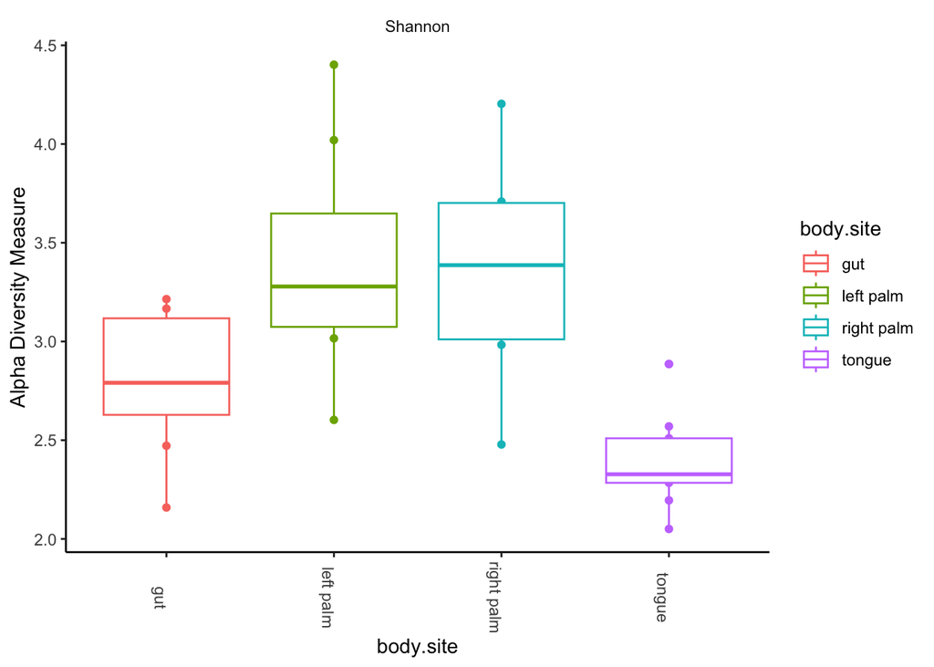

```r
plot_richness(ps.rarefied, x="body.site", measures= "Shannon", color = 'body.site') +
  geom_boxplot() +
  theme_classic() +
  theme(strip.background = element_blank(), axis.text.x.bottom = element_text(angle = -90))
```